# Give Me Some Credit

Competition on Kaggle. Goal is to improve on the state of the art in credit scoring by predicting the probability that somebody will experience financial distress in the next two years.

- The data preparation I did in R. See PreparacionDatos.R
- See FirstDataAnalysis.html and DimensionalityReduction.html for more details

## Predict Income with Linear Regresion

```python
# Import necessary modules
import pandas as pd
from sklearn.linear_model import LinearRegression
```

```python
# Import data
df = pd.read_csv('../dat/Train1.csv', sep=',')
df.head(10)
```

|  | SD | Age | RUUL | DebtRatio | Income | OpenCredit | REloans | Dep | no3059 | no6089 | no90 |
| --- | --- | --- | --- | --- | --- | --- | --- | --- | --- | --- | --- |
| 0 | 1 | 45 | 0.766127 | 0.802982 | 9120.0 | 13 | 6 | 2 | 2 | 0 | 0 |
| 1 | 0 | 40 | 0.957151 | 0.121876 | 2600.0 | 4 | 0 | 1 | 0 | 0 | 0 |
| 2 | 0 | 38 | 0.658180 | 0.085113 | 3042.0 | 2 | 0 | 0 | 1 | 0 | 1 |
| 3 | 0 | 30 | 0.233810 | 0.036050 | 3300.0 | 5 | 0 | 0 | 0 | 0 | 0 |
| 4 | 0 | 49 | 0.907239 | 0.024926 | 15370.0 | 7 | 1 | 0 | 1 | 0 | 0 |
| 5 | 0 | 74 | 0.213179 | 0.375607 | 3500.0 | 3 | 1 | 1 | 0 | 0 | 0 |
| 6 | 0 | 57 | 0.305682 | 0.366508 | NaN | 8 | 3 | 0 | 0 | 0 | 0 |
| 7 | 0 | 39 | 0.754464 | 0.209940 | 3500.0 | 8 | 0 | 0 | 0 | 0 | 0 |
| 8 | 0 | 27 | 0.116951 | 0.366508 | NaN | 2 | 0 | 0 | 0 | 0 | 0 |
| 9 | 0 | 57 | 0.189169 | 0.606291 | 15370.0 | 9 | 4 | 2 | 0 | 0 | 0 |

```python
df.Income.isnull().sum()
```

```
29731
```

```python
# Dropping SD
X = df.drop('SD', axis=1)

# Indexing NA's
NoIncome = X.Income.isnull()

# Making a traning set of rows with income
X_train = X[NoIncome == False].drop('Income', axis=1)
y_train = X[NoIncome == False].Income

# Making a set to predict on
X_impute = X[NoIncome == True].drop('Income', axis=1)
```

```python
# Doing linear regression to predict Income
model = LinearRegression(normalize=True)
model.fit(X_train, y_train)
y_hat = model.predict(X_impute)
```

```python
df.loc[NoIncome == True, 'Income'] = y_hat
df.to_csv('../dat/Train2.csv', index=False)
```

```python
from sklearn.model_selection import cross_val_score
scores = cross_val_score(model, X_train, y_train, cv=5, scoring='r2')
scores
```

```
array([0.33826844, 0.3321081 , 0.32236518, 0.33865509, 0.33602746])
```

```python
# Doing the same for the Test set
df = pd.read_csv('../dat/Test1.csv', sep=',') # Train3 are centralized & scaled data
X = df.drop('id', axis=1)

# Indexing NA's
NoIncome = X.Income.isnull()

# Making a traning set of rows with income
X_train = X[NoIncome == False].drop('Income', axis=1)
y_train = X[NoIncome == False].Income

# Making a set to predict on
X_impute = X[NoIncome == True].drop('Income', axis=1)
model.fit(X_train, y_train)
y_hat = model.predict(X_impute)

df.loc[NoIncome == True, 'Income'] = y_hat
df.to_csv('../dat/Test2.csv', index=False)
```

Data preparation continues in PreparacionDatos.R

## Logistic Regression

```python
# Import necessary modules
from sklearn.model_selection import train_test_split
from sklearn.linear_model import LogisticRegression
from sklearn import metrics
```

```python
# Import data
df = pd.read_csv('../dat/Train3.csv', sep=',') # Train3 are centralized & scaled data
X = df.drop('SD', axis=1)
y = df.SD
```

```python
# Split train/test
X_train, X_validation, y_train, y_validation = train_test_split(X, y, train_size=0.85, random_state=1234)
print(X_train.head())
print()
print(y_train.head())
```

```
            Age      RUUL    Income  OpenCredit   REloans       Dep  LateDays  \
2097  -0.087708 -0.817403  0.146141    0.494999  0.880263 -0.666680 -0.310308
60985 -0.629300 -0.080247  0.370622    1.077982  4.464714  1.141691 -0.310308
27126  0.115389 -0.763989  0.811400   -0.476639 -0.015849 -0.666680 -0.310308
57483  1.537070 -0.545037 -1.617554    0.300671 -0.015849 -0.666680 -0.310308
61582 -0.900097 -0.346730  0.529813    1.466637  0.880263 -0.666680 -0.310308

          Slack
2097  -0.851748
60985 -1.748724
27126  1.124358
57483 -1.431441
61582  0.297503

2097     0
60985    0
27126    0
57483    0
61582    0
Name: SD, dtype: int64
```

```python
# Logistic Regression
model = LogisticRegression(random_state=42)
model.fit(X_train, y_train)
y_hat = model.predict_proba(X_validation)[:,1]
fpr, tpr, thresholds = metrics.roc_curve(y_validation, y_hat)
metrics.auc(fpr, tpr) # 0.851339
```

```
0.8513390227904911
```

```python
# Making a file to understand ROC
val = pd.DataFrame()
val['y'] = y_validation
val['y_hat'] = y_hat
val.to_csv('../dat/val.csv', index=False)
```

In ROC.R I have shown that points with SD=0 get probabilities close to zero, but most points with SD=1 are also predicted as zero.

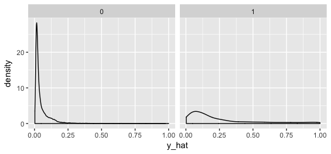

```python
from IPython.display import Image
Image("../img/pred_LR_unbalanceddata.png")
```

```python
# Retrain on all data
model.fit(X, y)
```

```
LogisticRegression(C=1.0, class_weight=None, dual=False, fit_intercept=True,
          intercept_scaling=1, max_iter=100, multi_class='ovr', n_jobs=1,
          penalty='l2', random_state=42, solver='liblinear', tol=0.0001,
          verbose=0, warm_start=False)
```

```python
# Submission file
X_test = pd.read_csv('../dat/Test3.csv', sep=',')
submisstion = pd.DataFrame()
submisstion['Id'] = X_test.id
submisstion['Probability'] = model.predict_proba(X_test.drop('id', axis=1))[:,1]
submisstion.to_csv("../sub/entry_LR.csv", index=False)
# Kaggle Private Score: 0.848701
```

```python
# Import balanced data
df = pd.read_csv('../dat/Train4.csv', sep=',') # Train4 are balanced data
X = df.drop('SD', axis=1)
y = df.SD

# Split train/test
X_train, X_validation, y_train, y_validation = train_test_split(X, y, train_size=0.85, random_state=1234)
```

```python
# Logistic Regression
model2 = LogisticRegression(random_state=42, max_iter=150)
model2.fit(X_train, y_train)
y_hat = model2.predict_proba(X_validation)[:,1]
fpr, tpr, thresholds = metrics.roc_curve(y_validation, y_hat)
metrics.auc(fpr, tpr) # 0.840419 < 0.851339
```

```
0.8404191543965676
```

Now what's going on here? Why is the AUC score getting worse. I will use ggplot to explain. See ROC.R

```python
# Making a file to understand ROC
val = pd.DataFrame()
val['y'] = y_validation
val['y_hat'] = y_hat
val.to_csv('../dat/val2.csv', index=False)
```

It is shown in ROC.R that the probability densities for SD=0 is much wider, but now the points with SD=1 are predicted better.

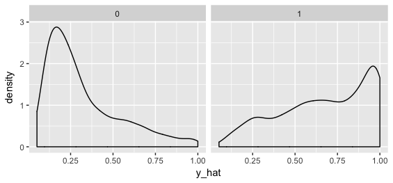

```python
Image("../img/pred_LR_balanceddata.png")
```

```python
# Retrain on all data
model2.fit(X, y)
```

```
LogisticRegression(C=1.0, class_weight=None, dual=False, fit_intercept=True,
          intercept_scaling=1, max_iter=150, multi_class='ovr', n_jobs=1,
          penalty='l2', random_state=42, solver='liblinear', tol=0.0001,
          verbose=0, warm_start=False)
```

```python
# Submission file
X_test = pd.read_csv('../dat/Test3.csv', sep=',')
submisstion = pd.DataFrame()
submisstion['Id'] = X_test.id
submisstion['Probability'] = model2.predict_proba(X_test.drop('id', axis=1))[:,1]
submisstion.to_csv("../Sub/entryLR2.csv", index=False)
# Kaggle Private Score: 0.854717 > 0.848701
```

## SVM

```python
# Import necessary modules
from sklearn.model_selection import GridSearchCV
from sklearn.svm import SVC
```

```python
# Import data
df = pd.read_csv('../dat/Train4.csv', sep=',') # Train4 are balanced data
X = df.drop('SD', axis=1)
y = df.SD
# Split train/test
X_train, X_validation, y_train, y_validation = train_test_split(X, y, train_size=0.85, random_state=1234)
```

```python
# SVM
model = SVC(probability=True, random_state=42, verbose=True)
model.fit(X_train, y_train)
y_hat = model.predict_proba(X_validation)[:,1]
fpr, tpr, thresholds = metrics.roc_curve(y_validation, y_hat)
metrics.auc(fpr, tpr) # 0.830859
```

```
[LibSVM]
```

```
0.8308587558882107
```

## Cross Validation to see which kernel & parameters are best

```python
# CV
tuned_parameters = [{'kernel': ['rbf'], 'C': [1, 0.5, 0.1, 0.05, 0.001]},
                    {'kernel': ['linear'], 'C': [1]}]

clf = GridSearchCV(SVC(probability=True), tuned_parameters, cv=5, scoring='roc_auc')
clf.fit(X_train, y_train)
```

```
GridSearchCV(cv=5, error_score='raise',
       estimator=SVC(C=1.0, cache_size=200, class_weight=None, coef0=0.0,
  decision_function_shape='ovr', degree=3, gamma='auto', kernel='rbf',
  max_iter=-1, probability=True, random_state=None, shrinking=True,
  tol=0.001, verbose=False),
       fit_params=None, iid=True, n_jobs=1,
       param_grid=[{'kernel': ['rbf'], 'C': [1, 0.5, 0.1, 0.05, 0.001]}, {'kernel': ['linear'], 'C': [1]}],
       pre_dispatch='2*n_jobs', refit=True, return_train_score=True,
       scoring='roc_auc', verbose=0)
```

```python
print("Best parameters set found on training set:")
print()
print(clf.best_params_)
```

```
Best parameters set found on training set:

{'C': 1, 'kernel': 'linear'}
```

```python
print("Grid scores on training set:")
print()
means = clf.cv_results_['mean_test_score']
stds = clf.cv_results_['std_test_score']
for mean, std, params in zip(means, stds, clf.cv_results_['params']):
    print("%0.3f (+/-%0.03f) for %r"
          % (mean, std * 2, params))
```

```
Grid scores on training set:

0.843 (+/-0.011) for {'C': 1, 'kernel': 'rbf'}
0.844 (+/-0.011) for {'C': 0.5, 'kernel': 'rbf'}
0.847 (+/-0.010) for {'C': 0.1, 'kernel': 'rbf'}
0.847 (+/-0.010) for {'C': 0.05, 'kernel': 'rbf'}
0.829 (+/-0.007) for {'C': 0.001, 'kernel': 'rbf'}
0.851 (+/-0.011) for {'C': 1, 'kernel': 'linear'}
```

The AUC score of 0.843 is different than above, but CV shows that the linear kernel is better.

```python
# Submission file
X_test = pd.read_csv('../Dat/Test3.csv', sep=',')
submisstion = pd.DataFrame()
submisstion['Id'] = X_test.id
submisstion['Probability'] = clf.predict_proba(X_test.drop('id', axis=1))[:,1]
submisstion.to_csv("../sub/entrySVM.csv", index=False)
# Kaggle Private Score: 0.851283 < 0.854717 (LR)
```

The score didn't improve.

## Neural Network

```python
# Import necessary modules
from keras.layers import Dense, Dropout
from keras.models import Sequential
from keras.utils import to_categorical
from keras.layers.normalization import BatchNormalization
from keras.models import load_model
from keras.callbacks import EarlyStopping
```

```python
# Import balanced data
df = pd.read_csv('../dat/Train4.csv', sep=',')

# Getting predictors/target
predictors = df.drop(['SD'], axis=1).as_matrix()
target = to_categorical(df.SD)
```

```python
# Specify the model
n_cols = predictors.shape[1]
model = Sequential()
model.add(Dense(100, activation='relu', input_shape = (n_cols,)))
model.add(Dense(100, activation='relu'))
model.add(Dense(100, activation='relu'))
model.add(Dense(2, activation='softmax'))

# Compile the model
model.compile(optimizer='adam',
              loss='categorical_crossentropy',
              metrics=['accuracy'])

# Early stopping
early_stopping_monitor = EarlyStopping(patience=2)

# Fit the model
model_train = model.fit(predictors, target, epochs=10, batch_size=64, validation_split=0.2,
                        callbacks=[early_stopping_monitor])
```

```
Train on 16041 samples, validate on 4011 samples
```

```python
# Train on all the data
model_train = model.fit(predictors, target, epochs=5, batch_size=64, validation_split=0.0)

# Save the model
model.save('../mod/model_NN_file.h5')
```

```python
# Import Test data
df_in = pd.read_csv('../dat/Test3.csv', sep=',')
id = df_in.id
predictors = df_in.drop(['id'], axis=1).as_matrix()

# Make predictions
predictions = model.predict(predictors)
prob_true = predictions[:,1]
```

```python
# Make submission file
d = {'Id': id, 'Probability': prob_true}
df_out = pd.DataFrame(data=d)
df_out.to_csv("../sub/entryNN.csv", index=False) # Private Score: 0.849695
```

```python
# Using dropout

df = pd.read_csv('../dat/Train4.csv', sep=',')
predictors = df.drop(['SD'], axis=1).as_matrix()
target = to_categorical(df.SD)

model = Sequential()
model.add(Dense(100, activation='relu', input_shape = (n_cols,)))
model.add(Dropout(0.5))
model.add(Dense(100, activation='relu'))
model.add(Dropout(0.5))
model.add(Dense(100, activation='relu'))
model.add(Dropout(0.5))
model.add(Dense(2, activation='softmax'))

model.compile(optimizer='adam',
              loss='categorical_crossentropy',
              metrics=['accuracy'])

early_stopping_monitor = EarlyStopping(patience=2)

model_train = model.fit(predictors, target, epochs=10, batch_size=64, validation_split=0.2,
                        callbacks=[early_stopping_monitor])
```

```
Train on 16041 samples, validate on 4011 samples
```

```python
# Train on all the data
model_train = model.fit(predictors, target, epochs=9, batch_size=64, validation_split=0.0)

# Save the model
model.save('../mod/model_NN_dropout_file.h5')
```

```python
# Import Test data
df_in = pd.read_csv('../dat/Test3.csv', sep=',')
id = df_in.id
predictors = df_in.drop(['id'], axis=1).as_matrix()
# Make predictions
predictions = model.predict(predictors)
prob_true = predictions[:,1]
# Make submission file
d = {'Id': id, 'Probability': prob_true}
df_out = pd.DataFrame(data=d)
df_out.to_csv("../sub/entryNN_dropout.csv", index=False) # Private Score: 0.863577 > 0.849695
```

So dropout improves things. Now let's use all the data:

```python
# Import training data
df = pd.read_csv('../dat/Train3.csv', sep=',')

# Getting predictors/target
predictors = df.drop(['SD'], axis=1).as_matrix()
target = to_categorical(df.SD)

# Specify the model
n_cols = predictors.shape[1]
model = Sequential()
model.add(Dense(100, activation='relu', input_shape = (n_cols,)))
model.add(Dense(100, activation='relu'))
model.add(Dense(100, activation='relu'))
model.add(Dense(2, activation='softmax'))

# Compile the model
model.compile(optimizer='adam',
              loss='categorical_crossentropy',
              metrics=['accuracy'])

# Early stopping
early_stopping_monitor = EarlyStopping(patience=2)

# Fit the model
model_train = model.fit(predictors, target, epochs=5, batch_size=64, validation_split=0.2,
                        callbacks=[early_stopping_monitor])

# Save the model
model.save('../mod/model_NN2_file.h5')
```

```
Train on 120000 samples, validate on 30000 samples
```

```python
# Import Test data
df_in = pd.read_csv('../dat/Test3.csv', sep=',')
id = df_in.id
predictors = df_in.drop(['id'], axis=1).as_matrix()
# Make predictions
predictions = model.predict(predictors)
prob_true = predictions[:,1]
# Make submission file
d = {'Id': id, 'Probability': prob_true}
df_out = pd.DataFrame(data=d)
df_out.to_csv("../sub/entryNN2.csv", index=False) # Private Score: 0.865048 > 0.863577 (balanced data with dropout)
```

A bit better. But the val_acc is way off...

## XGBoost

This algorithm is used a lot on Kaggle

```python
# Import necessary modules
from xgboost import XGBClassifier
```

```python
# Import balanced data
df = pd.read_csv('../dat/Train4.csv', sep=',')
X = df.drop('SD', axis=1)
y = df.SD

# Split train/test
X_train, X_validation, y_train, y_validation = train_test_split(X, y, train_size=0.85, random_state=1234)
```

```python
# fit model to training data
model = XGBClassifier()
model.fit(X_train, y_train)

print(model)
```

```
XGBClassifier(base_score=0.5, booster='gbtree', colsample_bylevel=1,
       colsample_bytree=1, gamma=0, learning_rate=0.1, max_delta_step=0,
       max_depth=3, min_child_weight=1, missing=None, n_estimators=100,
       n_jobs=1, nthread=None, objective='binary:logistic', random_state=0,
       reg_alpha=0, reg_lambda=1, scale_pos_weight=1, seed=None,
       silent=True, subsample=1)
```

```python
# make predictions for validation data
y_hat = model.predict_proba(X_validation)[:,1]
fpr, tpr, thresholds = metrics.roc_curve(y_validation, y_hat)
metrics.auc(fpr, tpr) # 0.852031
```

```
0.8520313360021398
```

```python
# Submission file
X_test = pd.read_csv('../dat/Test3.csv', sep=',')
submission = pd.DataFrame()
submission['Id'] = X_test.id
submission['Probability'] = model.predict_proba(X_test.drop('id', axis=1))[:,1]
submission.to_csv("../sub/entryXGB.csv", index=False)
# Kaggle Private Score: 0.864961 < 0.865048 (NN2)
```

## CatBoost

Let's try gradient boosting, even though there are no categorical data

```python
# Import necessary modules
from catboost import CatBoostClassifier
```

```python
# Import the complete dataset
df = pd.read_csv('../dat/Train3.csv', sep=',')
X = df.drop('SD', axis=1)
y = df.SD

# Split train/test
X_train, X_validation, y_train, y_validation = train_test_split(X, y, train_size=0.85, random_state=1234)
```

```python
# CatBoost
model = CatBoostClassifier(use_best_model=True, eval_metric='AUC', random_seed=42)
model.fit(X_train, y_train, eval_set=(X_validation, y_validation), plot=True)
# bestTest=0.868023
model.save_model('../mod/catboost_model.dump')
```

```
0:	learn: 0.8245978	test: 0.8247804	best: 0.8247804 (0)	total: 161ms	remaining: 2m 41s
1:	learn: 0.8419706	test: 0.8405759	best: 0.8405759 (1)	total: 244ms	remaining: 2m 1s
2:	learn: 0.8486678	test: 0.8492977	best: 0.8492977 (2)	total: 329ms	remaining: 1m 49s
3:	learn: 0.8487828	test: 0.8495018	best: 0.8495018 (3)	total: 403ms	remaining: 1m 40s
4:	learn: 0.8530539	test: 0.8562698	best: 0.8562698 (4)	total: 479ms	remaining: 1m 35s
5:	learn: 0.8522742	test: 0.8540906	best: 0.8562698 (4)	total: 553ms	remaining: 1m 31s
6:	learn: 0.8517832	test: 0.8530502	best: 0.8562698 (4)	total: 625ms	remaining: 1m 28s
7:	learn: 0.8532651	test: 0.8545759	best: 0.8562698 (4)	total: 695ms	remaining: 1m 26s
8:	learn: 0.8534204	test: 0.8546549	best: 0.8562698 (4)	total: 766ms	remaining: 1m 24s
9:	learn: 0.8543476	test: 0.8563822	best: 0.8563822 (9)	total: 839ms	remaining: 1m 23s
10:	learn: 0.8544126	test: 0.8562936	best: 0.8563822 (9)	total: 911ms	remaining: 1m 21s
```

```
11:	learn: 0.8545764	test: 0.8563552	best: 0.8563822 (9)	total: 997ms	remaining: 1m 22s
12:	learn: 0.8548078	test: 0.8565924	best: 0.8565924 (12)	total: 1.07s	remaining: 1m 21s
13:	learn: 0.8543616	test: 0.8555795	best: 0.8565924 (12)	total: 1.15s	remaining: 1m 20s
14:	learn: 0.8550660	test: 0.8561500	best: 0.8565924 (12)	total: 1.23s	remaining: 1m 21s
15:	learn: 0.8555272	test: 0.8567495	best: 0.8567495 (15)	total: 1.32s	remaining: 1m 20s
16:	learn: 0.8550907	test: 0.8562752	best: 0.8567495 (15)	total: 1.39s	remaining: 1m 20s
17:	learn: 0.8556433	test: 0.8567703	best: 0.8567703 (17)	total: 1.47s	remaining: 1m 19s
18:	learn: 0.8562314	test: 0.8575653	best: 0.8575653 (18)	total: 1.54s	remaining: 1m 19s
19:	learn: 0.8563037	test: 0.8575615	best: 0.8575653 (18)	total: 1.61s	remaining: 1m 19s
20:	learn: 0.8566147	test: 0.8582307	best: 0.8582307 (20)	total: 1.69s	remaining: 1m 18s
21:	learn: 0.8564735	test: 0.8582432	best: 0.8582432 (21)	total: 1.76s	remaining: 1m 18s
22:	learn: 0.8568045	test: 0.8585165	best: 0.8585165 (22)	total: 1.84s	remaining: 1m 18s
23:	learn: 0.8569864	test: 0.8586598	best: 0.8586598 (23)	total: 1.93s	remaining: 1m 18s
24:	learn: 0.8568851	test: 0.8587339	best: 0.8587339 (24)	total: 2.02s	remaining: 1m 18s
25:	learn: 0.8571134	test: 0.8589314	best: 0.8589314 (25)	total: 2.1s	remaining: 1m 18s
26:	learn: 0.8572979	test: 0.8590103	best: 0.8590103 (26)	total: 2.2s	remaining: 1m 19s
27:	learn: 0.8573087	test: 0.8588490	best: 0.8590103 (26)	total: 2.31s	remaining: 1m 20s
28:	learn: 0.8575856	test: 0.8590897	best: 0.8590897 (28)	total: 2.4s	remaining: 1m 20s
29:	learn: 0.8575873	test: 0.8589452	best: 0.8590897 (28)	total: 2.49s	remaining: 1m 20s
30:	learn: 0.8577414	test: 0.8589233	best: 0.8590897 (28)	total: 2.57s	remaining: 1m 20s
31:	learn: 0.8577222	test: 0.8589407	best: 0.8590897 (28)	total: 2.65s	remaining: 1m 20s
32:	learn: 0.8577419	test: 0.8590356	best: 0.8590897 (28)	total: 2.73s	remaining: 1m 19s
33:	learn: 0.8578039	test: 0.8591305	best: 0.8591305 (33)	total: 2.81s	remaining: 1m 19s
34:	learn: 0.8579841	test: 0.8593976	best: 0.8593976 (34)	total: 2.92s	remaining: 1m 20s
35:	learn: 0.8580077	test: 0.8594256	best: 0.8594256 (35)	total: 3.05s	remaining: 1m 21s
36:	learn: 0.8579492	test: 0.8593555	best: 0.8594256 (35)	total: 3.14s	remaining: 1m 21s
37:	learn: 0.8580617	test: 0.8593276	best: 0.8594256 (35)	total: 3.22s	remaining: 1m 21s
38:	learn: 0.8580379	test: 0.8593790	best: 0.8594256 (35)	total: 3.31s	remaining: 1m 21s
39:	learn: 0.8582377	test: 0.8594957	best: 0.8594957 (39)	total: 3.39s	remaining: 1m 21s
40:	learn: 0.8581625	test: 0.8596359	best: 0.8596359 (40)	total: 3.47s	remaining: 1m 21s
41:	learn: 0.8582300	test: 0.8596963	best: 0.8596963 (41)	total: 3.55s	remaining: 1m 20s
42:	learn: 0.8583512	test: 0.8598433	best: 0.8598433 (42)	total: 3.63s	remaining: 1m 20s
43:	learn: 0.8583863	test: 0.8599209	best: 0.8599209 (43)	total: 3.73s	remaining: 1m 21s
44:	learn: 0.8585065	test: 0.8599925	best: 0.8599925 (44)	total: 3.84s	remaining: 1m 21s
45:	learn: 0.8588685	test: 0.8604804	best: 0.8604804 (45)	total: 3.94s	remaining: 1m 21s
46:	learn: 0.8588384	test: 0.8604907	best: 0.8604907 (46)	total: 4.03s	remaining: 1m 21s
47:	learn: 0.8589180	test: 0.8604873	best: 0.8604907 (46)	total: 4.11s	remaining: 1m 21s
48:	learn: 0.8589474	test: 0.8605337	best: 0.8605337 (48)	total: 4.19s	remaining: 1m 21s
49:	learn: 0.8590624	test: 0.8606666	best: 0.8606666 (49)	total: 4.27s	remaining: 1m 21s
50:	learn: 0.8593432	test: 0.8609750	best: 0.8609750 (50)	total: 4.36s	remaining: 1m 21s
```

[output cut: 939 more lines]

```
990:	learn: 0.8760756	test: 0.8679666	best: 0.8680230 (841)	total: 1m 23s	remaining: 762ms
991:	learn: 0.8760865	test: 0.8679585	best: 0.8680230 (841)	total: 1m 23s	remaining: 677ms
992:	learn: 0.8760950	test: 0.8679494	best: 0.8680230 (841)	total: 1m 24s	remaining: 592ms
993:	learn: 0.8761006	test: 0.8679525	best: 0.8680230 (841)	total: 1m 24s	remaining: 508ms
994:	learn: 0.8761098	test: 0.8679508	best: 0.8680230 (841)	total: 1m 24s	remaining: 423ms
995:	learn: 0.8761224	test: 0.8679577	best: 0.8680230 (841)	total: 1m 24s	remaining: 339ms
996:	learn: 0.8761318	test: 0.8679749	best: 0.8680230 (841)	total: 1m 24s	remaining: 254ms
997:	learn: 0.8761450	test: 0.8679753	best: 0.8680230 (841)	total: 1m 24s	remaining: 169ms
998:	learn: 0.8761499	test: 0.8679830	best: 0.8680230 (841)	total: 1m 24s	remaining: 84.6ms
999:	learn: 0.8761588	test: 0.8679847	best: 0.8680230 (841)	total: 1m 24s	remaining: 0us

bestTest = 0.8680230125
bestIteration = 841

Shrink model to first 842 iterations.
```

```python
# Retrain on all data
model2 = CatBoostClassifier(eval_metric='AUC', random_seed=42, iterations=842)
model2.fit(X, y)
```

```
0:	learn: 0.8302831	total: 78.7ms	remaining: 1m 6s
1:	learn: 0.8399039	total: 157ms	remaining: 1m 5s
2:	learn: 0.8434166	total: 241ms	remaining: 1m 7s
3:	learn: 0.8490646	total: 329ms	remaining: 1m 8s
4:	learn: 0.8482052	total: 411ms	remaining: 1m 8s
5:	learn: 0.8488247	total: 506ms	remaining: 1m 10s
6:	learn: 0.8483913	total: 591ms	remaining: 1m 10s
7:	learn: 0.8504622	total: 669ms	remaining: 1m 9s
8:	learn: 0.8514274	total: 745ms	remaining: 1m 8s
9:	learn: 0.8512384	total: 826ms	remaining: 1m 8s
10:	learn: 0.8512596	total: 904ms	remaining: 1m 8s
11:	learn: 0.8517208	total: 982ms	remaining: 1m 7s
12:	learn: 0.8528593	total: 1.06s	remaining: 1m 7s
13:	learn: 0.8542708	total: 1.14s	remaining: 1m 7s
14:	learn: 0.8544102	total: 1.23s	remaining: 1m 7s
15:	learn: 0.8544906	total: 1.32s	remaining: 1m 8s
16:	learn: 0.8549625	total: 1.4s	remaining: 1m 8s
17:	learn: 0.8549230	total: 1.48s	remaining: 1m 7s
18:	learn: 0.8553404	total: 1.57s	remaining: 1m 7s
19:	learn: 0.8552099	total: 1.65s	remaining: 1m 7s
20:	learn: 0.8551725	total: 1.73s	remaining: 1m 7s
21:	learn: 0.8554442	total: 1.81s	remaining: 1m 7s
22:	learn: 0.8557291	total: 1.89s	remaining: 1m 7s
23:	learn: 0.8559618	total: 1.97s	remaining: 1m 7s
24:	learn: 0.8564160	total: 2.06s	remaining: 1m 7s
25:	learn: 0.8564010	total: 2.14s	remaining: 1m 7s
26:	learn: 0.8565763	total: 2.22s	remaining: 1m 7s
27:	learn: 0.8565332	total: 2.31s	remaining: 1m 7s
28:	learn: 0.8566028	total: 2.41s	remaining: 1m 7s
29:	learn: 0.8568433	total: 2.49s	remaining: 1m 7s
30:	learn: 0.8572433	total: 2.58s	remaining: 1m 7s
31:	learn: 0.8575228	total: 2.67s	remaining: 1m 7s
32:	learn: 0.8574192	total: 2.75s	remaining: 1m 7s
33:	learn: 0.8575540	total: 2.84s	remaining: 1m 7s
34:	learn: 0.8575884	total: 2.92s	remaining: 1m 7s
35:	learn: 0.8575377	total: 3s	remaining: 1m 7s
36:	learn: 0.8574124	total: 3.1s	remaining: 1m 7s
37:	learn: 0.8574662	total: 3.18s	remaining: 1m 7s
38:	learn: 0.8576582	total: 3.26s	remaining: 1m 7s
39:	learn: 0.8578337	total: 3.35s	remaining: 1m 7s
```

[output cut: 787 more lines]

```
827:	learn: 0.8735813	total: 1m 14s	remaining: 1.27s
828:	learn: 0.8735920	total: 1m 15s	remaining: 1.18s
829:	learn: 0.8736078	total: 1m 15s	remaining: 1.09s
830:	learn: 0.8736107	total: 1m 15s	remaining: 996ms
831:	learn: 0.8736169	total: 1m 15s	remaining: 905ms
832:	learn: 0.8736233	total: 1m 15s	remaining: 815ms
833:	learn: 0.8736279	total: 1m 15s	remaining: 724ms
834:	learn: 0.8736380	total: 1m 15s	remaining: 634ms
835:	learn: 0.8736507	total: 1m 15s	remaining: 543ms
836:	learn: 0.8736704	total: 1m 15s	remaining: 453ms
837:	learn: 0.8736894	total: 1m 15s	remaining: 362ms
838:	learn: 0.8736920	total: 1m 15s	remaining: 272ms
839:	learn: 0.8736998	total: 1m 16s	remaining: 181ms
840:	learn: 0.8737089	total: 1m 16s	remaining: 90.5ms
841:	learn: 0.8737132	total: 1m 16s	remaining: 0us
```

```
<catboost.core.CatBoostClassifier at 0x1234f3940>
```

```python
# Submission file
X_test = pd.read_csv('../dat/Test3.csv', sep=',')
submisstion = pd.DataFrame()
submisstion['Id'] = X_test.id
submisstion['Probability'] = model2.predict(X_test.drop('id', axis=1), prediction_type='Probability')[:, 1]
submisstion.to_csv("../sub/CatBoost.csv", index=False)
# Kaggle Private Score: 0.866595 > 0.865048 (NN2)
```

So CatBoost does the best, although only marginal better than NN2 and XGBoost.

## Stacking different models

```python
# Import balanced data
df = pd.read_csv('../dat/Train4.csv', sep=',')
X = df.drop('SD', axis=1)
y = df.SD

# Split train/test
X_train, X_validation, y_train, y_validation = train_test_split(X, y, train_size=0.85, random_state=1234)

Ensemble = pd.DataFrame()

# LR
model1 = LogisticRegression(random_state=42)
model1.fit(X_train, y_train)
y_hat = model1.predict_proba(X_validation)[:,1]
Ensemble['P1'] = y_hat

# SVM
model2 = SVC(kernel='linear', probability=True, random_state=42, verbose=False)
model2.fit(X_train, y_train)
y_hat = model2.predict_proba(X_validation)[:,1]
Ensemble['P2'] = y_hat

# Import NN2 model
model3 = load_model('../mod/model_NN2_file.h5')
y_hat = model3.predict(X_validation)[:,1]
Ensemble['P3'] = y_hat

# XGB
model4 = XGBClassifier()
model4.fit(X_train, y_train)
y_hat = model4.predict_proba(X_validation)[:,1]
Ensemble['P4'] = y_hat

# CatBoost
model5 = CatBoostClassifier(use_best_model=True, random_seed=42)
model5.fit(X_train, y_train, eval_set=(X_validation, y_validation), plot=False)
y_hat = model5.predict(X_validation, prediction_type='Probability')[:,1]
Ensemble['P5'] = y_hat
```

```
0:	learn: 0.6790714	test: 0.6793701	best: 0.6793701 (0)	total: 43.5ms	remaining: 43.4s
1:	learn: 0.6665653	test: 0.6669388	best: 0.6669388 (1)	total: 72.1ms	remaining: 36s
2:	learn: 0.6545779	test: 0.6552052	best: 0.6552052 (2)	total: 92.8ms	remaining: 30.8s
3:	learn: 0.6428998	test: 0.6438863	best: 0.6438863 (3)	total: 113ms	remaining: 28.2s
4:	learn: 0.6318861	test: 0.6333356	best: 0.6333356 (4)	total: 133ms	remaining: 26.5s
5:	learn: 0.6223340	test: 0.6241419	best: 0.6241419 (5)	total: 153ms	remaining: 25.4s
6:	learn: 0.6130668	test: 0.6151800	best: 0.6151800 (6)	total: 172ms	remaining: 24.4s
7:	learn: 0.6046905	test: 0.6072759	best: 0.6072759 (7)	total: 192ms	remaining: 23.8s
8:	learn: 0.5962184	test: 0.5991196	best: 0.5991196 (8)	total: 212ms	remaining: 23.4s
9:	learn: 0.5888879	test: 0.5919074	best: 0.5919074 (9)	total: 232ms	remaining: 23s
10:	learn: 0.5818331	test: 0.5851562	best: 0.5851562 (10)	total: 259ms	remaining: 23.3s
11:	learn: 0.5754502	test: 0.5789187	best: 0.5789187 (11)	total: 278ms	remaining: 22.9s
12:	learn: 0.5690732	test: 0.5728284	best: 0.5728284 (12)	total: 296ms	remaining: 22.4s
13:	learn: 0.5632605	test: 0.5672102	best: 0.5672102 (13)	total: 314ms	remaining: 22.1s
14:	learn: 0.5578841	test: 0.5622027	best: 0.5622027 (14)	total: 332ms	remaining: 21.8s
15:	learn: 0.5523156	test: 0.5571975	best: 0.5571975 (15)	total: 353ms	remaining: 21.7s
16:	learn: 0.5476209	test: 0.5527456	best: 0.5527456 (16)	total: 373ms	remaining: 21.6s
17:	learn: 0.5432629	test: 0.5486846	best: 0.5486846 (17)	total: 392ms	remaining: 21.4s
18:	learn: 0.5387962	test: 0.5447273	best: 0.5447273 (18)	total: 411ms	remaining: 21.2s
19:	learn: 0.5351833	test: 0.5413951	best: 0.5413951 (19)	total: 430ms	remaining: 21.1s
20:	learn: 0.5318311	test: 0.5382019	best: 0.5382019 (20)	total: 450ms	remaining: 21s
21:	learn: 0.5282084	test: 0.5346906	best: 0.5346906 (21)	total: 474ms	remaining: 21.1s
22:	learn: 0.5247699	test: 0.5317252	best: 0.5317252 (22)	total: 495ms	remaining: 21s
23:	learn: 0.5213990	test: 0.5287011	best: 0.5287011 (23)	total: 514ms	remaining: 20.9s
24:	learn: 0.5182893	test: 0.5259846	best: 0.5259846 (24)	total: 533ms	remaining: 20.8s
25:	learn: 0.5155884	test: 0.5237929	best: 0.5237929 (25)	total: 553ms	remaining: 20.7s
26:	learn: 0.5131364	test: 0.5215265	best: 0.5215265 (26)	total: 572ms	remaining: 20.6s
27:	learn: 0.5107636	test: 0.5195228	best: 0.5195228 (27)	total: 591ms	remaining: 20.5s
28:	learn: 0.5084495	test: 0.5174536	best: 0.5174536 (28)	total: 612ms	remaining: 20.5s
29:	learn: 0.5061069	test: 0.5152682	best: 0.5152682 (29)	total: 632ms	remaining: 20.4s
30:	learn: 0.5041642	test: 0.5134941	best: 0.5134941 (30)	total: 651ms	remaining: 20.4s
31:	learn: 0.5020424	test: 0.5115565	best: 0.5115565 (31)	total: 670ms	remaining: 20.3s
32:	learn: 0.5000944	test: 0.5098019	best: 0.5098019 (32)	total: 692ms	remaining: 20.3s
33:	learn: 0.4984534	test: 0.5083332	best: 0.5083332 (33)	total: 712ms	remaining: 20.2s
34:	learn: 0.4967503	test: 0.5067598	best: 0.5067598 (34)	total: 732ms	remaining: 20.2s
35:	learn: 0.4950571	test: 0.5052069	best: 0.5052069 (35)	total: 753ms	remaining: 20.2s
36:	learn: 0.4938750	test: 0.5041414	best: 0.5041414 (36)	total: 772ms	remaining: 20.1s
37:	learn: 0.4923936	test: 0.5028734	best: 0.5028734 (37)	total: 790ms	remaining: 20s
38:	learn: 0.4909620	test: 0.5017080	best: 0.5017080 (38)	total: 810ms	remaining: 20s
39:	learn: 0.4896599	test: 0.5006497	best: 0.5006497 (39)	total: 831ms	remaining: 19.9s
```

[output cut: 1014 more lines]

[output not shown]

[output not shown]

```python
print(Ensemble.head(10))
```

```
         P1        P2        P3        P4        P5
0  0.291514  0.258990  0.032082  0.288339  0.227246
1  0.878187  0.876818  0.350525  0.859425  0.880365
2  0.727407  0.733582  0.312894  0.761351  0.775626
3  0.999945  1.000000  0.632587  0.982476  0.968968
4  0.957238  0.954362  0.458793  0.921297  0.918647
5  0.232397  0.224353  0.021052  0.211375  0.180778
6  0.262492  0.251957  0.029303  0.245539  0.245636
7  0.241202  0.247520  0.045191  0.300581  0.288700
8  0.317804  0.282360  0.040289  0.234564  0.232026
9  0.259723  0.233616  0.020742  0.153502  0.127836
```

When P1, P2, P4 & P5 give a high probability, P3 (NN) still gives a low probabilities

```python
# Training Ensemble
model6 = LogisticRegression(random_state=42)
model6.fit(Ensemble, y_validation)
y_hat = model6.predict_proba(Ensemble)[:,1]
fpr, tpr, thresholds = metrics.roc_curve(y_validation, y_hat)
metrics.auc(fpr, tpr) # 0.853831
```

```
0.8538306803687993
```

```python
# Submission file
X_test = pd.read_csv('../sub/entryLR2.csv', sep=',')
X_test.rename(columns={'Probability': 'P1'}, inplace=True)
X_test['P2'] = pd.read_csv('../sub/entrySVM.csv', sep=',')['Probability']
X_test['P3'] = pd.read_csv('../sub/entryNN2.csv', sep=',')['Probability']
X_test['P4'] = pd.read_csv('../sub/entryXGB.csv', sep=',')['Probability']
X_test['P5'] = pd.read_csv('../sub/CatBoost.csv', sep=',')['Probability']
submisstion = pd.DataFrame()
submisstion['Id'] = X_test.Id
submisstion['Probability'] = model6.predict_proba(X_test.drop('Id', axis=1))[:,1]
submisstion.to_csv("../sub/entryStack.csv", index=False)
# Kaggle Private Score: 0.866506
```

## Ensemble of NN2 & CatBoost

```python
# Ensemble
submission = pd.read_csv('../sub/entryNN2.csv', sep=',')
submission.rename(columns={'Probability': 'P1'}, inplace=True)
submission['P2'] = pd.read_csv('../sub/CatBoost.csv', sep=',')['Probability']

# Taking the average of the predicted probabilities
submission['Probability'] = submission.drop('Id', axis=1).mean(axis = 1)
submission.drop(['P1', 'P2'], axis=1, inplace=True)
submission.to_csv("../sub/Ensemble.csv", index=False)
# Kaggle Private Score: 0.866615
```

This is the best score.